# pratique data management dplyr

```r
library(dplyr)
```

# Chargement des données

```r
load("fichiers_prepared.RData")
```

# Sélectionner les données qui vous paraissent pertinentes

## FINESS établissement

```r
finess_et <- finess_et%>%
  select(finessET,SIRET,cod_com,dep,APE,dateautor)
```

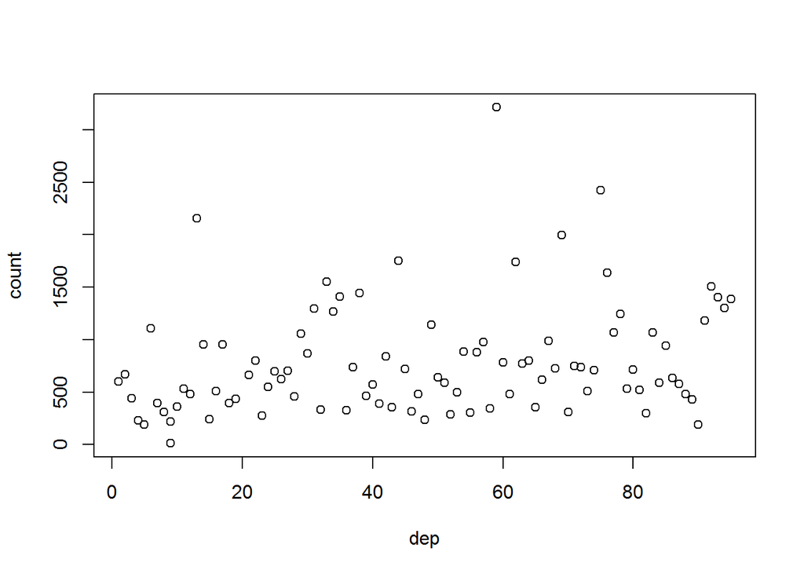

```r
finess_et%>%
  select(SIRET,dep)%>%
  distinct()%>%
  group_by(dep)%>%
  summarise(count=n())%>%plot
```

## FINESS Geolocalisation

On trouve 4 projections différentes :

```
## .
## LAMBERT_93    UTM_N20    UTM_N21    UTM_N22
##      94196       1032         12        234
```

On veut garder uniquement les établissements en France métropolitaine ie en coordonnées LAMBERT 93. On utilise une fonction similaire au `LIKE` dans SAS, il s’agit de `grep`/`grepl`. Cette fonction est héritée de la célèbre commande Linux du même nom. Son équivalent en invite de commande Windows est `findstr`. Des librairies R spécialisées dans la manipulation de chaînes de caractères proposent des implémentation plus rapides. On trouve [ici](https://rpubs.com/jonclayden/regex-performance) un benchmark intéressant.

```r
finess_geo$is_lambert=grepl("LAMBERT",finess_geo$source)
finess_geo <- finess_geo%>%filter(is_lambert)%>%select(-is_lambert)
```

## INSEE

```r
insee <- insee%>%
  select(CODGEO,NBMENFISC14,MED14,D114,D914)
```

# Retraitement des données

Toutes les variables sont traitées comme des char alors que seul codgeo le justifie.

```r
insee <- insee%>%mutate(CODGEO=as.factor(CODGEO))%>%
  mutate_if(is.character,as.numeric)
```

Les statistiques qui nous intéressent sont parfois manquantes

```r
insee%>%lapply(function(x)sum(is.na(x)))
```

```
## $CODGEO
## [1] 0
##
## $NBMENFISC14
## [1] 3647
##
## $MED14
## [1] 3647
##
## $D114
## [1] 31399
##
## $D914
## [1] 31399
```

Est-ce que ces communes co-incident avec nos établissement ?

# Jointure

Construction du codgeo dans finess_et

```r
nb_chiffres_cod_com=nchar(finess_et$cod_com)
nb_chiffres_cod_com%>%table
```

```
## .
##     1     2     3
##  3885 24645 67761
```

```r
finess_et[nb_chiffres_cod_com==1,]$cod_com <- paste0("00",finess_et[nb_chiffres_cod_com==1,]$cod_com)
finess_et[nb_chiffres_cod_com==2,]$cod_com <- paste0("0",finess_et[nb_chiffres_cod_com==2,]$cod_com)


finess_et <- finess_et%>%
  mutate(CODGEO=paste0(dep,cod_com),
         CODGEO=factor(CODGEO))
```

Comparaison des CODGEO FINESS et INSEE

```r
matching_fines_insee=!as.character(finess_et$CODGEO)%in%as.character(insee$CODGEO)
sum(matching_fines_insee)
```

```
## [1] 2097
```

```r
finess_et$CODGEO[matching_fines_insee]%>%as.character%>%head
```

```
## [1] "29084" "29083" "29084" "29083" "29083" "9A101"
```

```r
devtools::install_github("antuki/COGugaison")
```

```r
library(COGugaison)
```

```r
COG_akinator(c("29084","29083","29084","29083","29083","9A101"),donnees_insee = T)
```

```r
apparier_COG(vecteur_codgeo=c("29084","29083","29084","29083","29083","9A101"),COG=2014)$absent_de_COG
```

```
## [1] "9A101"
```

## Traitement CODGEO - Webscraping

On ne retrouve pas “9A101”. https://www.insee.fr/fr/metadonnees/cog/unite-urbaine/UU20109A101-saint-louis https://www.insee.fr/fr/recherche/recherche-geographique?geo=UU2010-9A101&debut=0 On peut scraper le site INSEE pour corriger ces unités urbaines, ou bien le faire à la main si elles sont assez rares.

## Jointure FINESS & INSEE par CODGEO

```r
finess_et_enrichi=merge(finess_et,insee,by="CODGEO",all.x=T)
```

## Statistique croisée FINESS & INSEE

```r
# library(Hmisc)
length(unique(finess_et$SIRET))
```

```
## [1] 76078
```

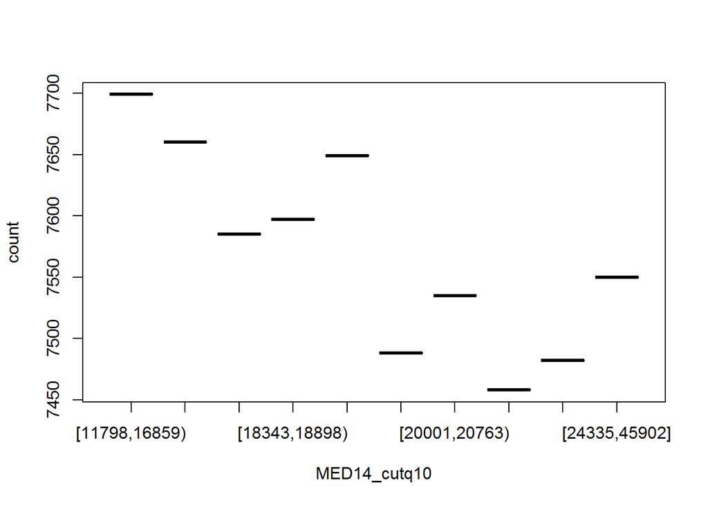

```r
siret_revenu_median=finess_et_enrichi%>%select(SIRET,MED14)%>%distinct
siret_revenu_median%>%mutate(MED14_cutq10=Hmisc::cut2(MED14,g = 10))%>%group_by(MED14_cutq10)%>%summarise(count=length(unique(SIRET)))%>%plot
```

# Bonus

## Compléter les valeurs manquantes dans insee avec des stats plus agrégées

```r
insee_epci=readxl::read_xls("base-cc-filosofi-2014.xls",sheet="EPCI")
names(insee_epci) <- insee_epci[5,]
insee_epci <- insee_epci[-(1:5),]
insee_epci <- insee_epci%>%
  select(CODGEO,NBMENFISC14,MED14,D114,D914)%>%
  mutate(CODGEO=as.factor(CODGEO))%>%
  mutate_if(is.character,as.numeric)%>%
  rename(EPCI=CODGEO)
insee_epci%>%lapply(function(x)sum(is.na(x)))
```

```
## $EPCI
## [1] 0
##
## $NBMENFISC14
## [1] 0
##
## $MED14
## [1] 0
##
## $D114
## [1] 70
##
## $D914
## [1] 70
```

Il faut maintenant récupérer la correspondance entre code commune et EPCI https://www.insee.fr/fr/information/2028028

```r
correspondance_path="https://www.insee.fr/fr/statistiques/fichier/2028028/table-appartenance-geo-communes-18.zip"
download.file(correspondance_path,destfile = "correspondance.zip",method="libcurl")
unzip("correspondance.zip")
```

```r
corres_com_epci=readxl::read_xls("table-appartenance-geo-communes-18.xls")
names(corres_com_epci) <- corres_com_epci[5,]
corres_com_epci <- corres_com_epci[-(1:5),]
corres_com_epci <- corres_com_epci%>%select(CODGEO,EPCI)
head(corres_com_epci)
```

```
## # A tibble: 6 x 2
##   CODGEO EPCI
##   <chr>  <chr>
## 1 01001  200069193
## 2 01002  240100883
## 3 01004  240100883
## 4 01005  200042497
## 5 01006  200040350
## 6 01007  240100883
```

```r
nrow(insee)
```

```
## [1] 36621
```

```r
nrow(merge(insee,corres_com_epci,by="CODGEO"))
```

```
## [1] 35274
```

```r
# On retombe sur le même problème de correspondance entre communes 2017 et communes 2014
insee <- merge(insee,corres_com_epci,by="CODGEO")
```

```r
insee_epci <- insee_epci%>%mutate(EPCI=as.character(EPCI))
insee_com_epci <- merge(insee,insee_epci,by="EPCI",all.x=T)

missingD914 <- is.na(insee_com_epci$D914.x)
sum(missingD914)
```

```
## [1] 30142
```

```r
insee_com_epci[missingD914,]$D914.x <- insee_com_epci[missingD914,]$D914.y
sum(is.na(insee_com_epci$D914.x))
```

```
## [1] 15280
```

Il reste encore beaucoup de valeurs manquantes, on peut encore utiliser les statistiques au niveau ARR, DEP, REG.